# Лабораторная работа №13

Презентация

Виноградова М. А.

Российский университет дружбы народов, Москва, Россия

9 мая 2025

# Информация

## Докладчик

- Виноградова Мария Андреевна
- Студентка (студ. билет 1132240691)
- группа НПИбд-01-24
- Российский университет дружбы народов
- 1132240691@pfur.ru
- https://github.com/mavinogradova/study_2024-2025_os-intro

# Цель работы

Изучить основы программирования в оболочке ОС UNIX. Научится писать более сложные командные файлы с использованием логических управляющих конструкций и циклов.

# Выполнение лабораторной работы

## 1. Используя команды getopts grep, написать командный файл, который анализирует командную строку с некоторыми ключами, а затем ищет в указанном файле нужные строки, определяемые ключом -p

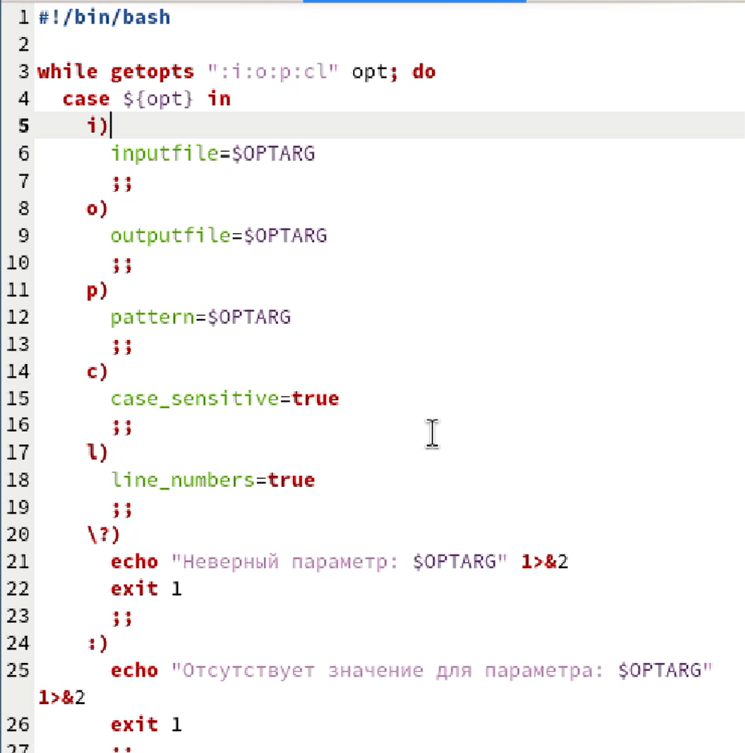

Пишем командный файл

## Проверяем работу командного файла:

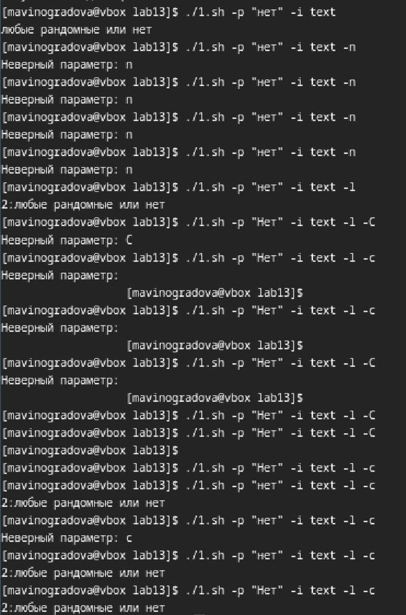

Смотрим реализацию

## 2. Написать на языке Си программу, которая вводит число и определяет, является ли оно больше нуля, меньше нуля или равно нулю

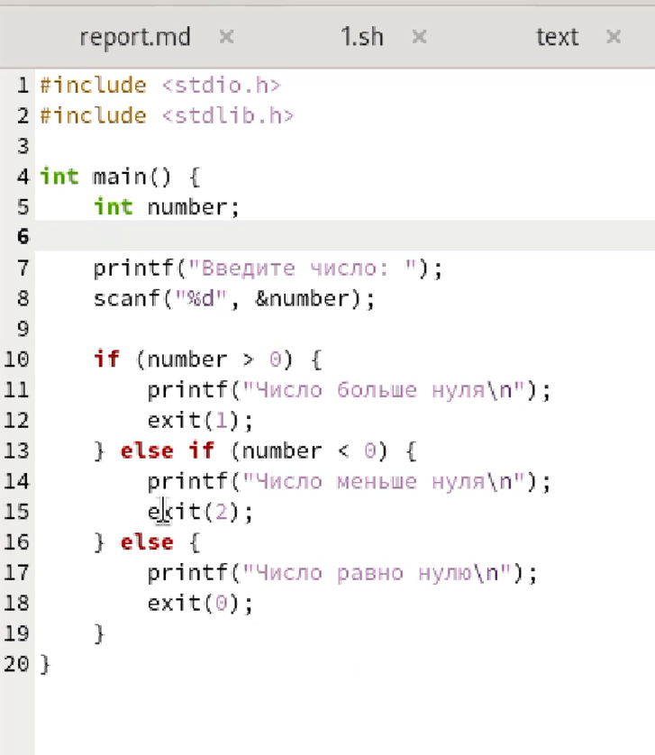

Пишем код

## 2.1. Командный файл должен вызывать эту программу и, проанализировав с помощью команды $?, выдать сообщение о том, какое число было введено

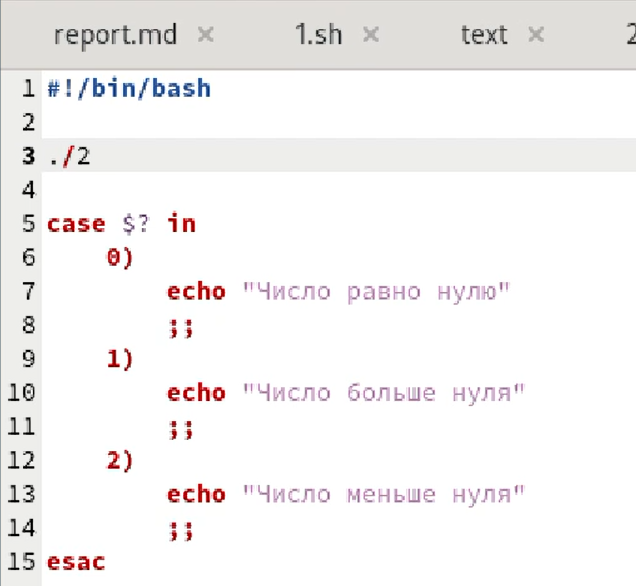

Пишем командный файл

## Проверяем работу командного файла и самого кода:

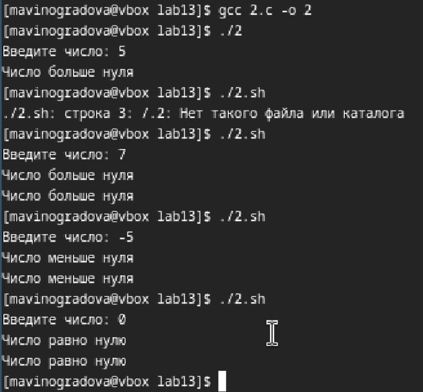

Смотрим реализацию

## 3. Написать командный файл, создающий указанное число файлов, пронумерованных последовательно от 1 до 𝑁. Этот же командный файл должен уметь удалять все созданные им файлы (если они существуют).

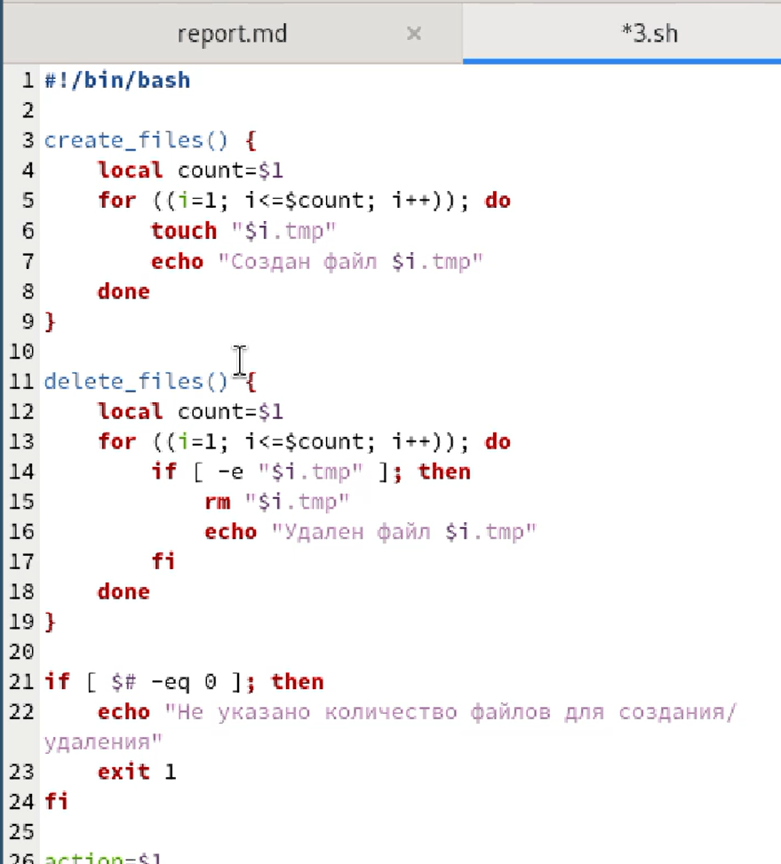

Пишем командный файл

## Проверяем работу командного файла:

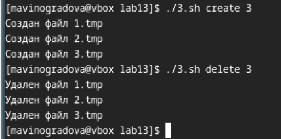

Смотрим реализацию

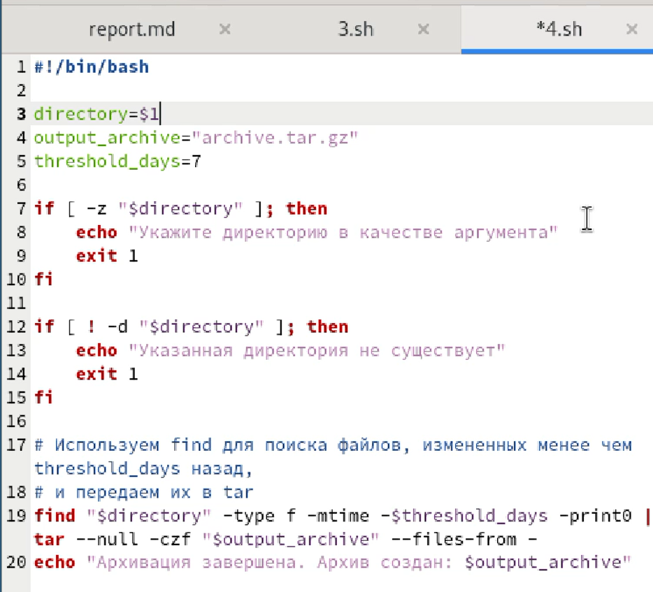

Пишем командный файл

## Проверяем работу командного файла:

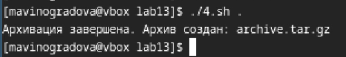

Смотрим реализацию

## Проверяем файлы в директории (распоковываем архив):

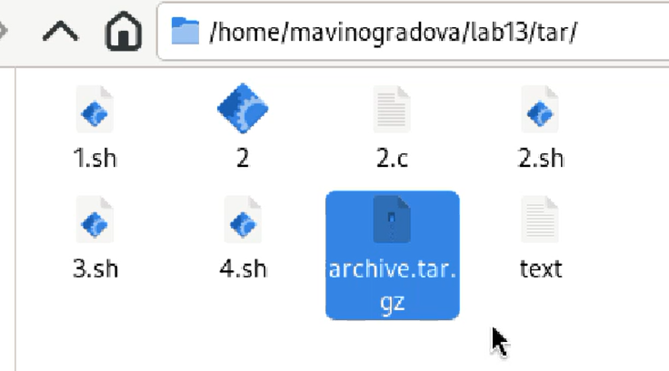

Проверяем архив

# Выводы

В ходе лабораторной работы изучены основы программирования в оболочке UNIX, освоено создание сложных командных файлов с использованием условных операторов, циклов и управляющих конструкций. Приобретённые навыки позволяют автоматизировать задачи в UNIX-подобных системах, повышая эффективность работы с командной строкой.